# FigureYa165heatmapPvalue

小丫画图出品

2020-3-1

欢迎关注“小丫画图”公众号，回复“小白”，看小视频，实现点鼠标跑代码。

小丫微信: epigenomics E-mail: figureya@126.com

作者：大鱼海棠

单位：中国药科大学国家天然药物重点实验室，生物统计与计算药学研究中心

小丫编辑校验

# 需求描述

热图展示亚型表达谱，并给出表达谱组间比较p值。

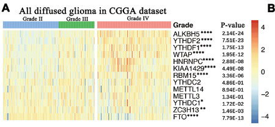

出自https://www.frontiersin.org/articles/10.3389/fonc.2019.01038

Figure 1. Expression of m6A RNA methylation regulators in gliomas with different clinicopathological features. (A-D) The expression levels of thirteen m6A RNA methylation regulators in gliomas with different WHO grades.

# 应用场景

针对两组或多组样本，做组间差异检验，提供4种常用非参或参数检验法：

- 两组，参数检验“t.test”, 非参数检验“wilcox”
- 多组，参数检验“anova”, 非参数检验“kruskal”

用热图展示亚型表达谱，并给出每个基因对应的表达谱组间比较p值。

# 环境设置

使用国内镜像安装包

```r
options("repos"= c(CRAN="https://mirrors.tuna.tsinghua.edu.cn/CRAN/"))
options(BioC_mirror="http://mirrors.ustc.edu.cn/bioc/")
```

加载包

```r
library(stringr)
library(pheatmap)
library(gplots)
library(grid)
Sys.setenv(LANGUAGE = "en") #显示英文报错信息
options(stringsAsFactors = FALSE) #禁止chr转成factor
```

加载自定义函数

```r
# 显示进程
display.progress = function (index, totalN, breakN=20) {

  if ( index %% ceiling(totalN/breakN)  ==0  ) {
    cat(paste(round(index*100/totalN), "% ", sep=""))
  }

}

# 计算组间统计差异
cross_subtype_compr <- function(expr = NULL,
                                subt = NULL,
                                subt.label = "Subtype",
                                two_sam_compr_method = "wilcox",
                                multi_sam_compr_method = "kruskal",
                                res.path = NULL) {

  if (!is.element(two_sam_compr_method, c("t.test", "wilcox"))) {stop("Two samples comparison should be t.test or wilcox!\n") }
  if (!is.element(multi_sam_compr_method, c("anova", "kruskal"))) {stop("multiple samples comparison should be kruskal or anova!\n") }

  subt.name <- unique(subt[,subt.label])
  n.subt <- length(subt.name)
  if(n.subt < 2) {stop("The number of subtype should be greater than 2!\n")}

  comprTab <- NULL

  # 两个亚型且为非参数检验
  if(n.subt == 2 & two_sam_compr_method == "wilcox") {
    for (i in 1:nrow(expr)) {
      display.progress(index = i,totalN = nrow(expr))
      tmp1 <- as.numeric(expr[i,rownames(subt[which(subt[,subt.label] == subt.name[1]),,drop = F])])
      tmp2 <- as.numeric(expr[i,rownames(subt[which(subt[,subt.label] == subt.name[2]),,drop = F])])
      wt <- wilcox.test(tmp1,tmp2)
      comprTab <- rbind.data.frame(comprTab,
                                   data.frame(gene = rownames(expr)[i],
                                              nominal.p.value = wt$p.value,
                                              stringsAsFactors = F),
                                   stringsAsFactors = F)
    }
  }

  # 两个亚型且为参数检验
  if(n.subt == 2 & two_sam_compr_method == "t.test") {
    for (i in 1:nrow(expr)) {
      display.progress(index = i,totalN = nrow(expr))
      tmp1 <- as.numeric(expr[i,rownames(subt[which(subt[,subt.label] == subt.name[1]),,drop = F])])
      tmp2 <- as.numeric(expr[i,rownames(subt[which(subt[,subt.label] == subt.name[2]),,drop = F])])
      tt <- t.test(tmp1,tmp2)
      comprTab <- rbind.data.frame(comprTab,
                                   data.frame(gene = rownames(expr)[i],
                                              nominal.p.value = tt$p.value,
                                              stringsAsFactors = F),
                                   stringsAsFactors = F)
    }
  }

  # 多个亚型且为非参数检验
  if(n.subt > 2 & multi_sam_compr_method == "kruskal") {
    for (i in 1:nrow(expr)) {
      display.progress(index = i,totalN = nrow(expr))
      tmp.list <- list()
      for (n in 1:n.subt) {
        tmp.list[[n]] <- data.frame(value = as.numeric(expr[i,rownames(subt[which(subt[,subt.label] == subt.name[n]),,drop = F])]),
                                    subt = subt.name[n],
                                    stringsAsFactors = F)
      }
      tmp <- do.call(rbind,tmp.list)
      kt <- kruskal.test(value ~ subt,data = tmp)
      comprTab <- rbind.data.frame(comprTab,
                                   data.frame(gene = rownames(expr)[i],
                                              nominal.p.value = kt$p.value,
                                              stringsAsFactors = F),
                                   stringsAsFactors = F)
    }
  }

  # 多个亚型且为参数检验
  if(n.subt > 2 & multi_sam_compr_method == "anova") {
    for (i in 1:nrow(expr)) {
      display.progress(index = i,totalN = nrow(expr))
      tmp.list <- list()
      for (n in 1:n.subt) {
        tmp.list[[n]] <- data.frame(value = as.numeric(expr[i,rownames(subt[which(subt[,subt.label] == subt.name[n]),,drop = F])]),
                                    subt = subt.name[n],
                                    stringsAsFactors = F)
      }
      tmp <- do.call(rbind,tmp.list)
      at <- summary(aov(value ~ subt,data = tmp))
      comprTab <- rbind.data.frame(comprTab,
                                   data.frame(gene = rownames(expr)[i],
                                              nominal.p.value = at[[1]][1,5],
                                              stringsAsFactors = F),
                                   stringsAsFactors = F)
    }
  }

  # 调整p值
  comprTab$adjusted.p.value = p.adjust(comprTab$nominal.p.value,method = "BH")
  # 按p值排序
  #comprTab <- comprTab[order(comprTab$adjusted.p.value, decreasing = F),]

  write.table(comprTab,file.path(res.path,"comprTab.txt"),sep = "\t",row.names = F,quote = F)
  return(comprTab)
}
```

# 输入文件

如果你自己的数据已经整理成easy_input*文件的格式，就直接跳到“差异表达分析”。

## 输入文件的下载

基因表达矩阵，CGGA.mRNA_array_301_gene_level.20191128.txt，每行一个基因，每列一个sample。从CGGA下载：[Expression Data (gene level)](http://www.cgga.org.cn/download?file=download/20191128/CGGA.mRNA_array_301_gene_level.20191128.txt.zip&type=mRNA_array_301_gene_level&time=20191128) ，解压；

## 读取基因表达矩阵

```r
#exp_data <- read.table("CGGA.mRNA_array_301_gene_level.20191128.txt", header=T, row.names=1, sep="\t")
# 为方便传输，只保留小数点后1位
#write.csv(round(exp_data,1), "easy_input_expr_ori.csv", quote = F)
exp_data <- read.csv("easy_input_expr_all.csv", row.names = 1)
exp_data[1:3,1:3]
```

```
##       CGGA_11 CGGA_124 CGGA_126
## A1BG     -0.4      0.6      0.3
## A1CF      2.3      1.2      2.2
## A2BP1     0.0      1.1      0.3
```

## 读取分组信息

用到两列：CGGA_ID和Grade

```r
clinical_data <- read.table("CGGA.mRNA_array_301_clinical.20191128.txt", header=T, sep="\t")
clinical_data <- clinical_data[!is.na(clinical_data$Grade), ]
clinical_data[1,]
```

```
##   CGGA_ID TCGA_subtypes PRS_type Histology  Grade Gender Age  OS Censor
## 1 CGGA_11     Classical  Primary       GBM WHO IV Female  57 155      1
##   Radio_status Chemo_status IDH_mutation_status X1p19q_Codeletion_status
## 1            1            0            Wildtype                     <NA>
```

```r
Subtype <- data.frame(Subtype = clinical_data$Grade)
row.names(Subtype) <- clinical_data$CGGA_ID
# 保存到文件，便于模仿格式
write.csv(Subtype, "easy_input_group.csv", quote = F)
```

## 提取感兴趣的基因的表达矩阵

```r
# 读取基因名
mygene <- read.table("easy_input_gene.txt")$V1

# 获取感兴趣的基因表达谱
mygene_data <- exp_data[mygene, ]
mygene_data[1:5, 1:5]
```

```
##        CGGA_11 CGGA_124 CGGA_126 CGGA_168 CGGA_172
## ALKBH5    -0.2     -0.7      0.3      0.1      0.1
## YTHDF2     0.2      0.1     -0.2      0.0      0.4
## YTHDF1    -1.4     -0.5     -1.7     -0.4      0.9
## WTAP      -2.8      0.0     -0.5      0.2      1.6
## HNRNPC    -0.6     -0.5     -1.1     -0.2      0.7
```

```r
# 保存到文件
write.csv(mygene_data, "easy_input_expr.csv", quote = F)
```

# 差异表达分析

```r
## 读取感兴趣的基因表达矩阵
mygene_data <- read.csv("easy_input_expr.csv", row.names = 1)
# 或者读取全部基因的表达矩阵，后面画Top 20个基因
#mygene_data <- read.csv("easy_input_expr_all.csv", row.names = 1)
mygene_data[1:3, 1:3]
```

```
##        CGGA_11 CGGA_124 CGGA_126
## ALKBH5    -0.2     -0.7      0.3
## YTHDF2     0.2      0.1     -0.2
## YTHDF1    -1.4     -0.5     -1.7
```

```r
## 读取分组信息
Subtype <- read.csv("easy_input_group.csv", row.names = 1)
# 查看各组名字和sample数量，画图时要用
table(Subtype$Subtype)
```

```
##
##  WHO II WHO III  WHO IV
##     117      57     124
```

```r
## 取表达矩阵和分组信息中共有的sample
com_sam <- intersect(colnames(mygene_data),rownames(Subtype))
mygene_data <- mygene_data[,com_sam]
Subtype <- Subtype[com_sam,,drop = F]
head(Subtype)
```

```
##          Subtype
## CGGA_11   WHO IV
## CGGA_124  WHO IV
## CGGA_126  WHO IV
## CGGA_168  WHO IV
## CGGA_172  WHO IV
## CGGA_195  WHO IV
```

```r
## 用前面的自定义函数计算组间统计差异
comprTab <- cross_subtype_compr(expr = mygene_data, # 或log2(mygene_data + 1)，如果用参数检验，请注意对数转化；若非参均可
                                subt = Subtype,
                                #two_sam_compr_method = "wilcox", # 两组"t.test", "wilcox"
                                multi_sam_compr_method = "kruskal", # 多组"anova", "kruskal"
                                res.path = ".")
```

```
## 8% 15% 23% 31% 38% 46% 54% 62% 69% 77% 85% 92% 100%
```

```r
# 用全部基因来画
n.show_top_gene <- nrow(mygene_data)
# 或者取top 20个基因来画
#n.show_top_gene <- 20

# 按分组排序
subt.order <- Subtype[order(Subtype$Subtype),,drop = F]
indata <- mygene_data[comprTab$gene[1:n.show_top_gene],rownames(subt.order)]
```

# 开始画图

```r
# 数据标准化和边界设置
plotdata <- t(scale(t(indata)))
plotdata[plotdata > 2] <- 2
plotdata[plotdata < -2] <- -2

# 调整行名
blank <- "    " # 行名和p值之间的间隔
p.value <- comprTab$adjusted.p.value[1:n.show_top_gene]
sig.label <- ifelse(p.value < 0.001,"****",
                    ifelse(p.value < 0.005,"***",
                           ifelse(p.value < 0.01,"**",
                                  ifelse(p.value < 0.05,"*",""))))
p.label <- formatC(p.value, # 将p值变成保留两位小数的科学计数法
                   format = "e",
                   digits = 2)

add.label <- str_pad(paste0(rownames(plotdata),sig.label), # 固定行名宽度并再右侧补齐" "
                     max(nchar(paste0(rownames(plotdata),sig.label))),
                     side = "right")

annCol <- subt.order # 获得排序后的亚型注释信息，这里只有一个变量需要注释
colnames(annCol)[1] <- paste(str_pad(colnames(annCol)[1], # 注释列名补上"P-value"，宽度和刚才一致
                                     max(nchar(paste0(rownames(plotdata),sig.label))),
                                     side = "right"),
                             "P-value",
                             sep = blank)

annColors <- list(c("WHO II"="lightblue", "WHO III"="darkgreen", "WHO IV"="pink")) # 如果有多个变量要注释颜色请补充c()
names(annColors) <- colnames(annCol)[1] # 如果有多个变量要注释颜色请补充每张list的name

# 绘制热图
pheatmap(cellheight = 15, cellwidth = 1,
         mat = plotdata, # 输入数据
         scale = "none", # 不标准化因为数据已经被标准化
         annotation_col = annCol, # 列注释信息
         annotation_colors = annColors, # 列注释对应的颜色
         cluster_cols = F, # 列不聚类
         cluster_rows = F, # 行不聚类
         show_colnames = F, # 不显示列名
         show_rownames = T, # 显示基因名
         #annotation_legend = F, # 不显示图例
         labels_row = paste(add.label, p.label, sep=blank), # 自定义样本名义blank作间隔
         fontfamily = "mono", # 关键，使用fixed font而不是proportional font
         gaps_col = c(173), # 根据自己的数据设置空白间隔的位置
         filename = "heatmapPvalue.pdf")
```

[figure not shown]

# 后期处理

输出的pdf文件是矢量图，可使用Illustrator等矢量图工具打开，仿照例文将各个亚型的名字添加在annotation bar的上方。